# Managing rasters of future climates

SMARTER 2022 - Workshop in León

18/05/2022

Loading the ‘raster’ and ‘rgdal’ libraries:

```r
if (!require("raster")) install.packages("raster")
if (!require("rgdal")) install.packages("rgdal")
```

[output not shown]

List of the **.tif** and **.cpg / csv / dbf / prj / shp / shx** input files that need to be present in the working directory to reproduce the present script:

```r
list.files()
```

```
##  [1] "BIO01.tif"
##  [2] "ITA_adm0.cpg"
##  [3] "ITA_adm0.csv"
##  [4] "ITA_adm0.dbf"
##  [5] "ITA_adm0.prj"
##  [6] "ITA_adm0.shp"
##  [7] "ITA_adm0.shx"
##  [8] "Managing-raster-of-future-climates.Rmd"
##  [9] "Managing raster of future climates.Rmd"
## [10] "wc2.1_2.5m_bioc_BCC-CSM2-MR_ssp585_2061-2080.tif"
```

Import the shapefile of Italy (our study area in the practical) as retrieved from https://www.diva-gis.org/gdata:

```r
ita  <- readOGR(dsn = "./ITA_adm0.shp")
```

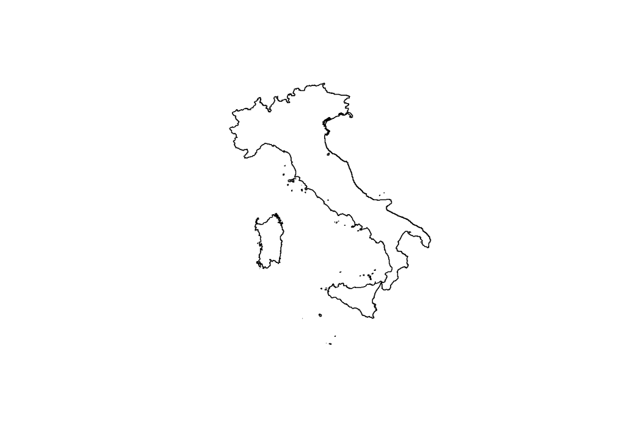

```r
plot(ita)
```

Loading the BIO08 layer projection to 2080 as downloaded from https://www.worldclim.org/data/cmip6/cmip6_clim2.5m.html: here, note the ‘band’ argument in the ‘raster’ function, where we need to select our layer of interest (i.e., the layer n.er 8 corresponding to the bioclimatic variable BIO08):

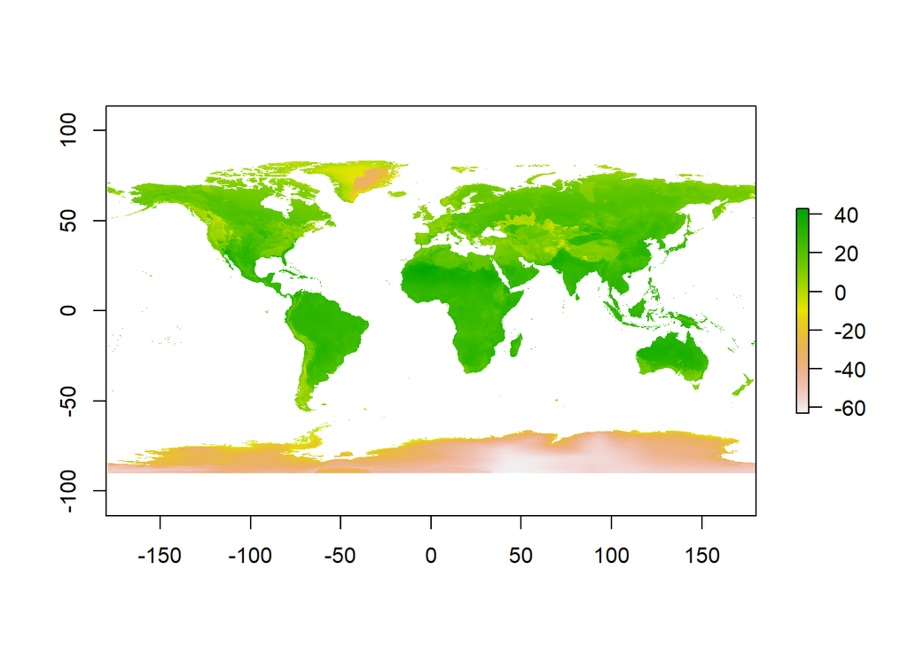

```r
bio8fut<- raster("./wc2.1_2.5m_bioc_BCC-CSM2-MR_ssp585_2061-2080.tif", band = 8)
plot(bio8fut)
```

Crop the extent of the world BIO08 raster layer in 2080 to the one of the shapefile of Italy:

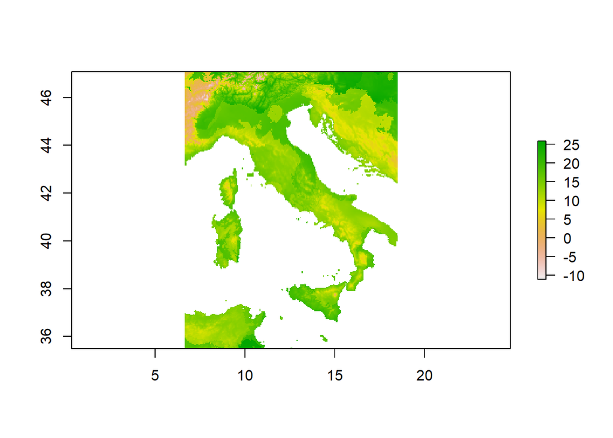

```r
bio8fut <- crop(bio8fut, ita)
plot(bio8fut)
```

Mask the new raster object to Italy only:

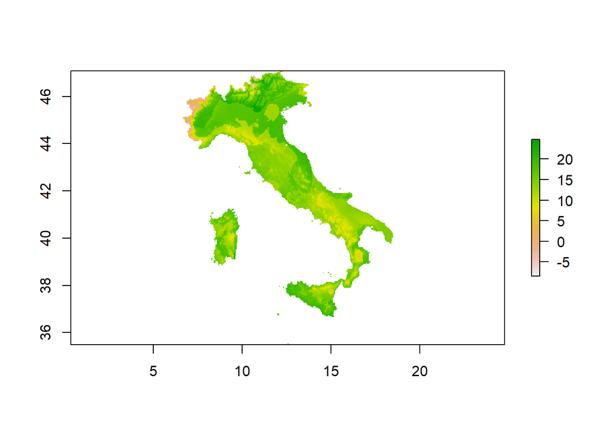

```r
bio8fut <- mask(bio8fut, ita, inverse=F)
plot(bio8fut)
```

Reproject the BIO08 layer in 2080 to the same resolution as the bioclimatic rasters representing present conditions (i.e., from 2.5 minues to 30 seconds), and save the new raster object in the working directory:

```r
r <- raster("BIO01.tif")
bio8fut <- projectRaster(bio8fut, r)
```

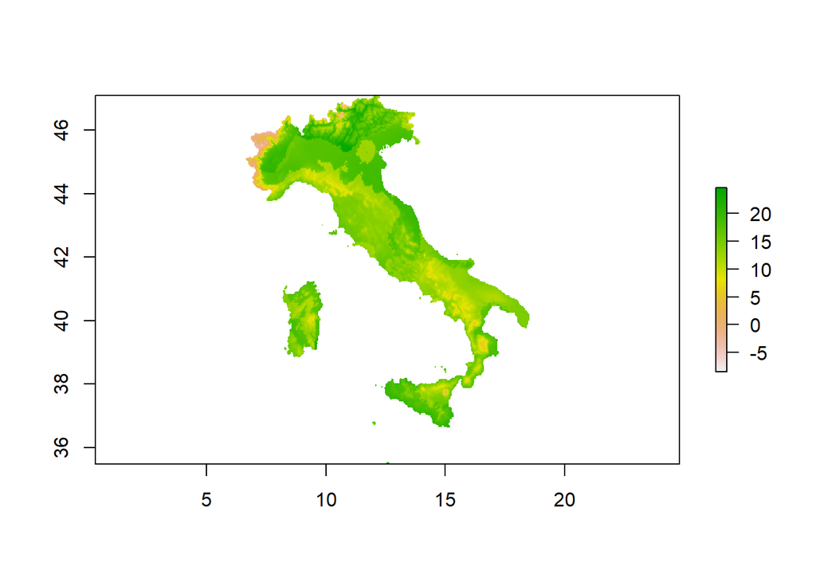

```r
plot(bio8fut)
```

```r
writeRaster(bio8fut, filename="BIO08-2080", format="raster", overwrite=TRUE)
```

```
## class      : RasterLayer
## dimensions : 1392, 1426, 1984992  (nrow, ncol, ncell)
## resolution : 0.008333333, 0.008333333  (x, y)
## extent     : 6.633333, 18.51667, 35.49167, 47.09167  (xmin, xmax, ymin, ymax)
## crs        : +proj=longlat +datum=WGS84 +no_defs
## source     : BIO08-2080.grd
## names      : wc2.1_2.5m_bioc_BCC.CSM2.MR_ssp585_2061.2080
## values     : -8.483334, 24.81667  (min, max)
```

The same procedure can be followed for BIO15:

```r
bio15fut<- raster("./wc2.1_2.5m_bioc_BCC-CSM2-MR_ssp585_2061-2080.tif", band = 15)
bio15fut <- crop(bio15fut, ita)
bio15fut <- mask(bio15fut, ita, inverse=F)
bio15fut <- projectRaster(bio15fut, r)
```

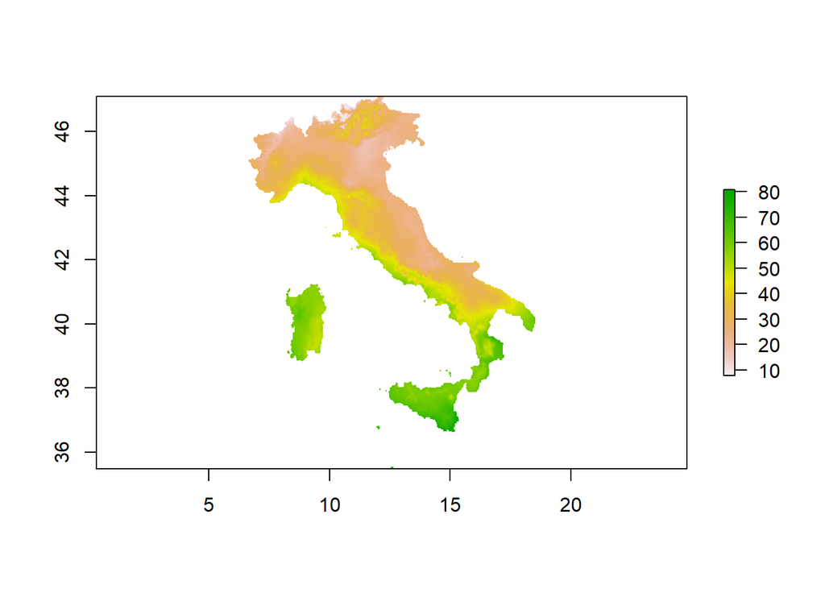

```r
plot(bio15fut)
```

```r
writeRaster(bio15fut, filename="BIO15-2080", format="raster", overwrite=TRUE)
```

```
## class      : RasterLayer
## dimensions : 1392, 1426, 1984992  (nrow, ncol, ncell)
## resolution : 0.008333333, 0.008333333  (x, y)
## extent     : 6.633333, 18.51667, 35.49167, 47.09167  (xmin, xmax, ymin, ymax)
## crs        : +proj=longlat +datum=WGS84 +no_defs
## source     : BIO15-2080.grd
## names      : wc2.1_2.5m_bioc_BCC.CSM2.MR_ssp585_2061.2080
## values     : 7.50172, 80.8147  (min, max)
```